# IntroR - Chapitre II - Visualisation Graphique

Pierre-O Goffard

17 janvier 2019

Nous allons voir comment utiliser la librairie **ggplot2** pour visualiser les données.

```r
library(ggplot2)
```

Il s’agit d’une composante de la librairie **tidyverse**.

Un graphique ggplot comprends les éléments de bases suivant

1. **ggplot(data = )** : Les données à visualiser
2. **geom_**: La forme géométrique pour visualiser les données, cela inclut la couleur des courbes, le remplissage des barre, la taille/forme/couleur des points.
3. **aes()**: Le lien entre les axes du graphique (X et Y) et les vatriables du jeu de données (à placer dans **ggplot** ou **geom_**)
4. **labs()**: Précise le nom des axes, du titre, de la légende
5. **theme()**: Apparence globale comprenant le fond, le quadrillage. Pour le texte: la police, sa taille et sa couleur.

D’autres éléments peuvent se rajouter comme

1. **xlim(), ylim()**: limiter la longeur des axes
2. **coord_**: Changer la projection des données sur les axes (**coord_polar()** ou **coord_flip()**), changer l’aspect ratio **coord_fixed()**
3. **scale_x_continuous** **scale_y_continuouss**: Changer l’échelle de graduation d’une variable quantitative
4. **theme_bw()** pour changer l’aspect global du graphique (par défaut **theme_gray()**)

# Analyse univariée

```r
library(insuranceData)
data(AutoClaims)
# Résumé statistiques des données
summary(AutoClaims)
```

```
##       STATE          CLASS      GENDER        AGE             PAID
##  STATE 15:2180   C11    :1151   F:2582   Min.   :50.00   Min.   :    9.5
##  STATE 02:1122   C71    :1129   M:4191   1st Qu.:54.00   1st Qu.:  523.7
##  STATE 04: 666   C7     : 913            Median :62.00   Median : 1001.7
##  STATE 06: 622   C6     : 911            Mean   :63.81   Mean   : 1853.0
##  STATE 17: 491   C1     : 726            3rd Qu.:72.00   3rd Qu.: 2137.4
##  STATE 03: 348   C7B    : 686            Max.   :97.00   Max.   :60000.0
##  (Other) :1344   (Other):1257
```

## Variable quantitative

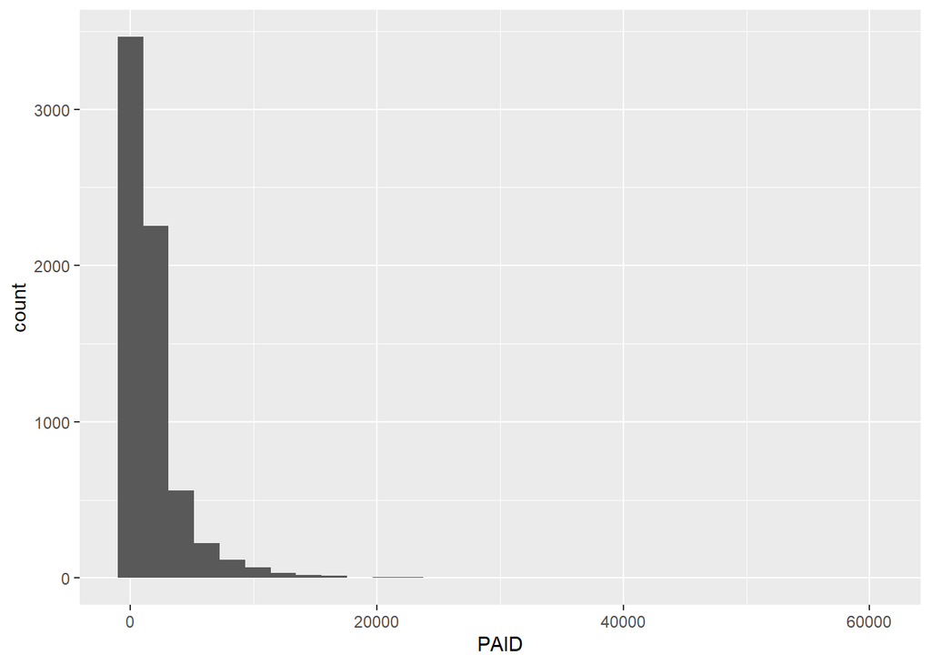

```r
# Repère cartésien et chargement des données
ggplot(data = AutoClaims, aes(x = PAID)) +
  # Histogramme
  geom_histogram()
```

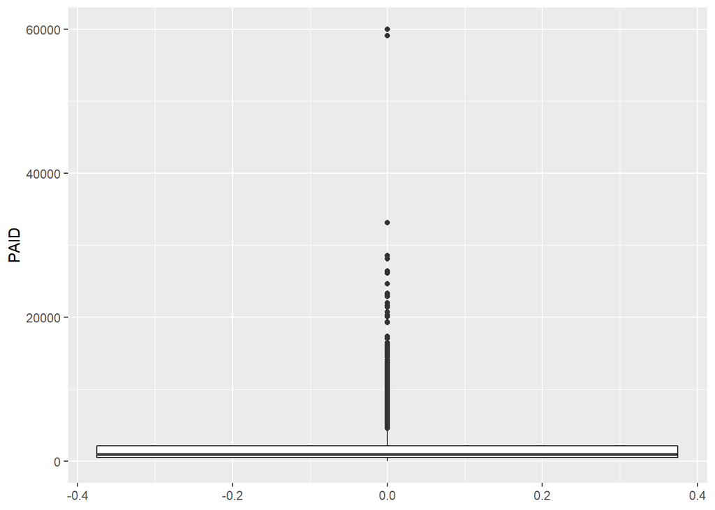

```r
ggplot(data = AutoClaims, aes(y = PAID)) +
  # Boîte à moustache
  geom_boxplot()
```

Vous pouvez tester l’alternative à la boxplot avec **geom_violin**, réduire l’échelle de l’axe y avec **ylim** pour lire plus facilement les quartiles et le mettre à l’horizontal via **coord_flip()**.

Nous allons maintenant customiser nos graphiques. Nous souhaitons

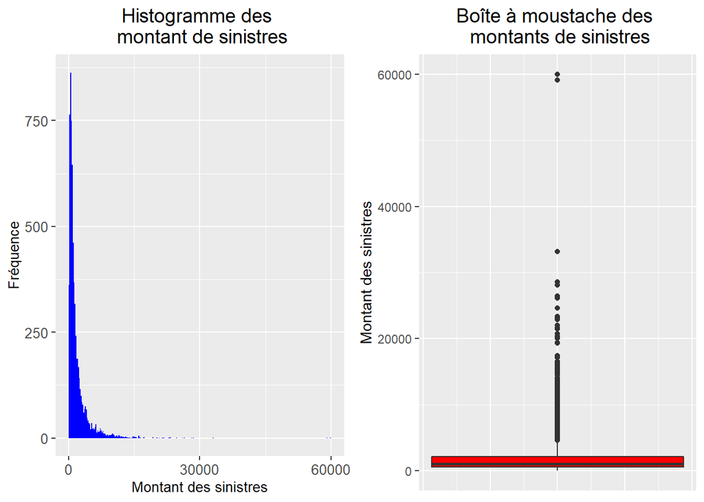

```r
# Librairie pour placer les graphiques l'un à côté de l'autre
library(gridExtra)
# Histogramme dans l'objet h
h <- ggplot(data = AutoClaims, aes(x = PAID)) +
  # Histogramme bleu avec moins de barres
  geom_histogram(fill = 'blue',
                 breaks =seq(0, 60000, 200)) +
  # Noms des axes et titres
  labs(x = "Montant des sinistres",
       y = "Fréquence",
       # \n permet d'aller à la ligne
       title = "Histogramme des \n montant de sinistres") +
  # Taille de la police et ajustement horizontal du titre entre 0 (à gauche)
  # et 1 (à droite)
  theme(axis.text.x = element_text(size = 10),
        axis.text.y = element_text(size = 10),
        axis.title.x = element_text(size = 10),
        axis.title.y = element_text(size = 10),
        plot.title = element_text(hjust = 1/2, size = 14)
        ) +
  scale_x_continuous(breaks = c(0, 30000, 60000))

# Boxplot dans l'objet b
b <- ggplot(data = AutoClaims, aes(y = PAID)) +
  # Boxplot rouge
  geom_boxplot( fill = 'red') +
  # Label axe des y
  labs(y = 'Montant des sinistres', title = 'Boîte à moustache des \n montants de sinistres') +
  theme(axis.text.x = element_blank(),
        axis.ticks.x = element_blank(),
        plot.title = element_text(hjust = 1/2, size = 14))

# Les deux graphiques l'un à côté de l'autre

grid.arrange(h, b, ncol=2)
```

## Variable qualitative

Nous allons utiliser le jeu de données **ozone.csv** comprenant des mesures d’ozone quotidiennes à Rennes.

```r
#Mac
#ozone <- read.csv2("~/Dropbox/PO/Enseignements/ISFA/R/BDD/ozone.csv")
#PC
ozone <- read.csv2("C:/Users/pierr/Dropbox/Enseignements/ISFA/R/BDD/ozone.csv")
```

La variable **vent** est une variable qualitative dont les modalités sont les directions du vent.

```r
# Effectifs pour chaque modalité
table(ozone$vent)
```

```
##
##   Est  Nord Ouest   Sud
##    10    31    50    21
```

Pour apprécier la répartition des directions de vents, on a recours à un diagramme en bar

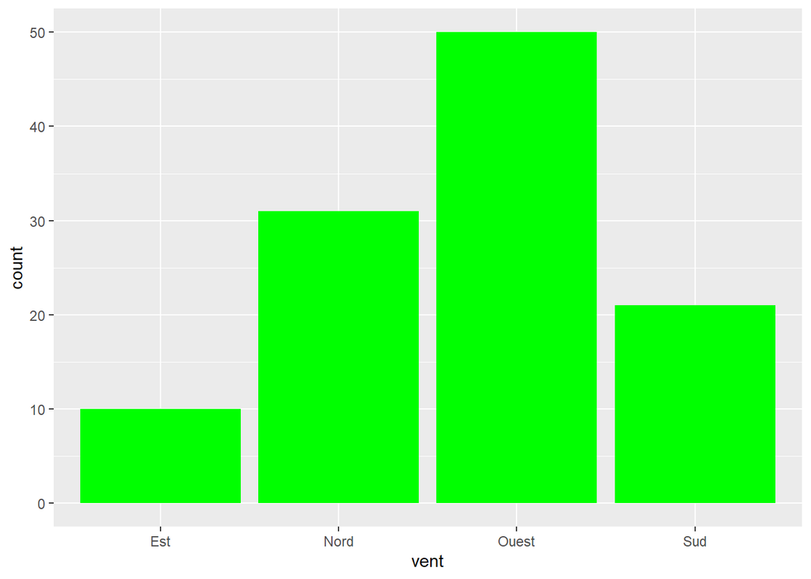

```r
ggplot(data = ozone,  aes(x = vent)) +
  # Diagramme en barre vert
  geom_bar(fill = 'green')
```

On peut personaliser le diagramme en bar et

- attribuer une couleur différente à chaque barre (**fill = variable** dans la fonction **aes()**).
- Afficher des proportions plutôts que les effectifs.

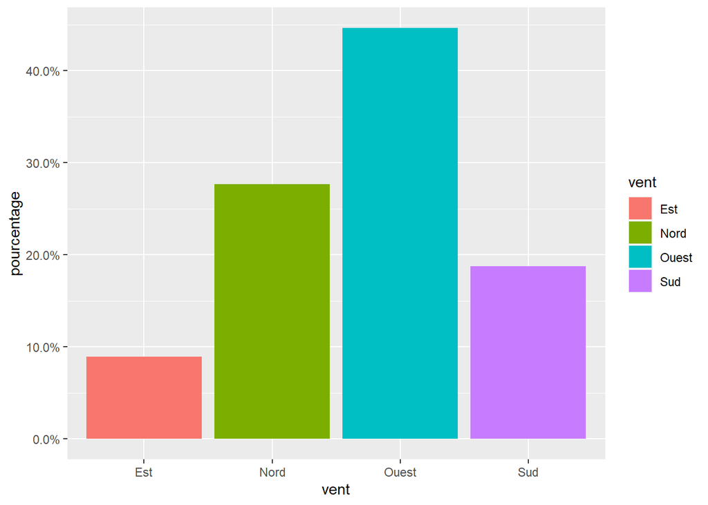

```r
library(scales)
ggplot(data = ozone) +
  # ..count.. est une variable calculée automatiquement lorsqu'on utilise geom_bar
  geom_bar(aes(x = vent, y = (..count..) / sum(..count..), fill = vent)) +
  scale_y_continuous(labels = percent) +
  labs( y = 'pourcentage')
```

```r
#   # Pour afficher les valeurs sous le format pourcentage
```

On peut aussi produire un diagramme en secteur, pour ce faire, il faut transformer le diagramme en bar via un passage en coordonnées polaires (**+ coord_polar()**).

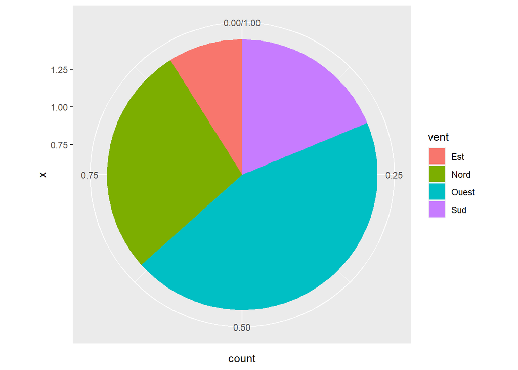

```r
ggplot(data = ozone) +
  #Diagramme en barre ne contenant qu'une seule barre
  geom_bar(mapping = aes(x = 1, fill = vent), position = 'fill') +
  # Passage en coordonnées polaires
  coord_polar(theta ='y')
```

On peut améliorer le visuel en supprimant l’axe qui s’intitule **x** et en plaçant des marqueurs aux points de démarcation des différents secteurs.

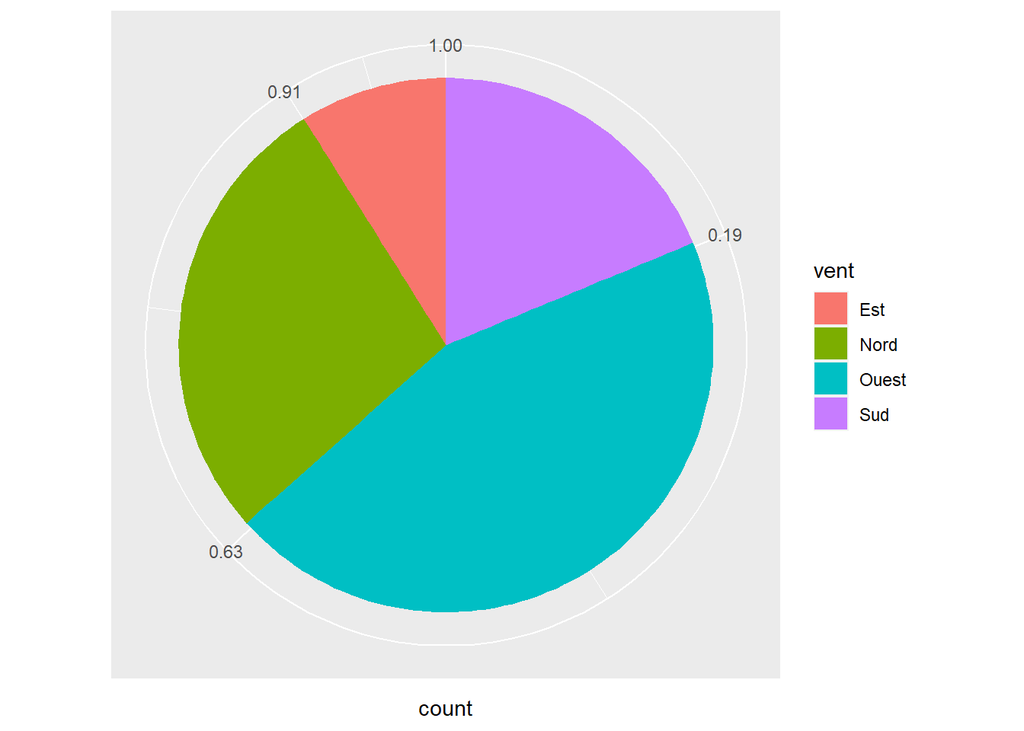

```r
# Récupération des pourcentages cummulés
cum_percent_vent <- cumsum(rev(table(ozone$vent))) / length(ozone$vent)
names(cum_percent_vent) <- NULL

ggplot(data = ozone) +
  #Diagramme en barre ne contenant qu'une seule barre
  geom_bar(mapping = aes(x = 1, fill = vent), position = 'fill') +
  # Passage en coordonnées polaires
  coord_polar(theta ='y') +
  # On place les marqueurs de manière adéquate
  scale_y_continuous(breaks = round(cum_percent_vent * 100) / 100) +
  # On efface tout ce qui concerne l'axe des y qui correspond au module en coordonées polaires
  theme(axis.text.y = element_blank(),
        axis.title.y = element_blank(),
        axis.ticks.y = element_blank()
        )
```

# Analyse bivariée

## Relation entre deux variables quantitatives

Lorsque l’on étudie deux variables quantitatives, on distingue généralement deux cas:

1. L’étude de la relation entre une variable à prédire $Y$ (réponse) et d’un prédicteur ou covariable $X$. Il s’agit d’une régression où l’on cherche à identifier une fonction $f$ telle que
   $$Y\approx f(X).$$
   On doit alors (en plus de calculer des coefficients de corrélation) tracer $Y$ en fonction de $X$.
2. L’étude d’une quantité au cours du temps, lorsqu’on a des observations à des intervalles de temps réguliers. On trace alors la fonction $X(t)$ en fonction du temps $t$, on parle dans ce cas de série temporelles. On cherche à observer des tendances et des saisonalités.

Nous pouvons commencer par tracer une fonction classique
$$f(x) = \sin(x)\text{, }x\in\mathbb{R}.$$
On crée un jeu de données contenant les valeurs pour $x$ (donnant les limites de l’axes des abscisses) et les valeurs pour $f(x)$ correspondantes. La fonction **geom_point** permet de produire des nuages de points.

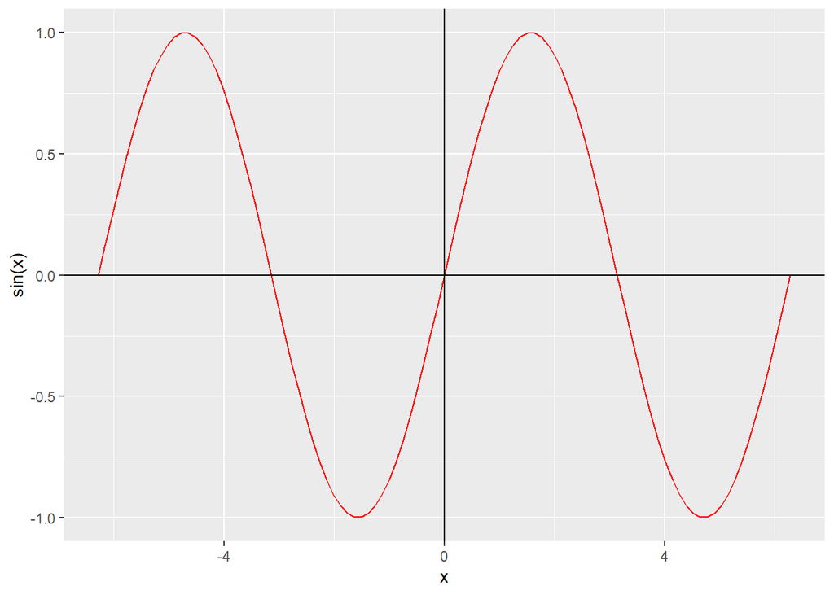

```r
grid <- seq(-2 * pi, 2 * pi, 4 * pi / 100)
values <- sin(grid)
sin_data <- data.frame(x = grid , f_x = values)
ggplot(data = sin_data,  mapping = aes(x = grid, y = f_x)) +
  # Traçage de la courbe
  geom_line(linetype="solid", color="red", size=0.5) +
  #Attribution d'un titre pour les axes
  xlab('x') + ylab('sin(x)') +
  # Dessine des lignes verticales et horizontales en guise d'axes
  geom_hline(yintercept = 0) + geom_vline(xintercept = 0)
```

Via le jeu de données **ozone**, nous pouvons étudier l’incidence de la température **T12** sur la hauteur du pic d’ozone mesuré **max03**.

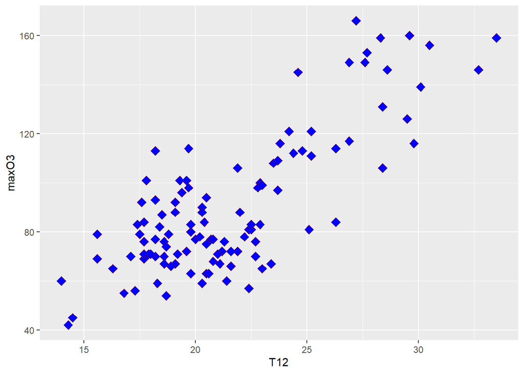

```r
ggplot(data = ozone, mapping = aes(x = T12, y = maxO3)) +
  # Nuage de point
  geom_point(shape=23, fill="blue", color="darkred", size=3)
```

Il est assez clair que les fortes températures influence positivement les mesures d’ozone! On peut calculer le coefficient de corrélation linéaire de Pearson

```r
# Coeficient de corrélation linéaire
cor(ozone$maxO3, ozone$T12)
```

```
## [1] 0.7842623
```

Nous allons maintenant étudier les fluctuation du cac 40 au cours du temps

```r
data(EuStockMarkets)
library(lubridate)
```

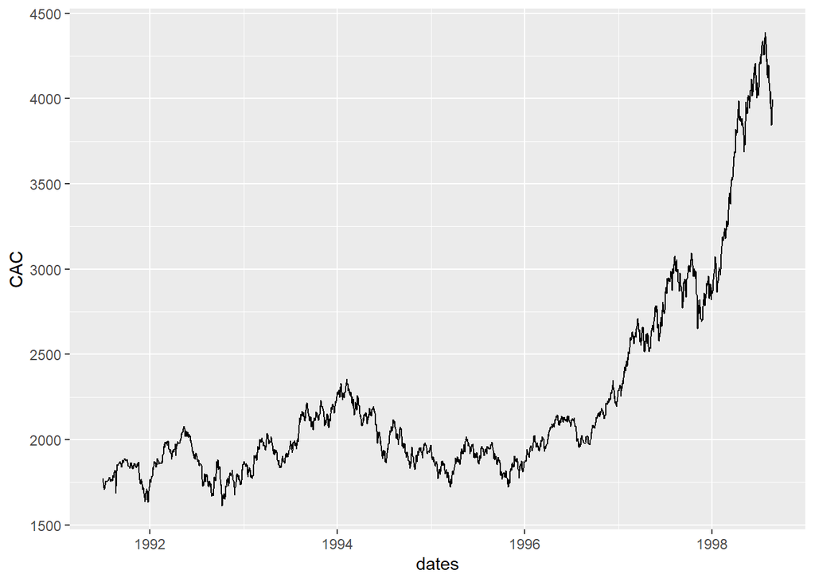

```r
EuStockMarkets_V1 <- data.frame(dates = date_decimal(as.numeric(time(EuStockMarkets))), EuStockMarkets)
ggplot(data = EuStockMarkets_V1, mapping = aes( x = dates, y = CAC)) + geom_line()
```

Nous pouvons ajouter l’évolution d’autres indices boursiers.

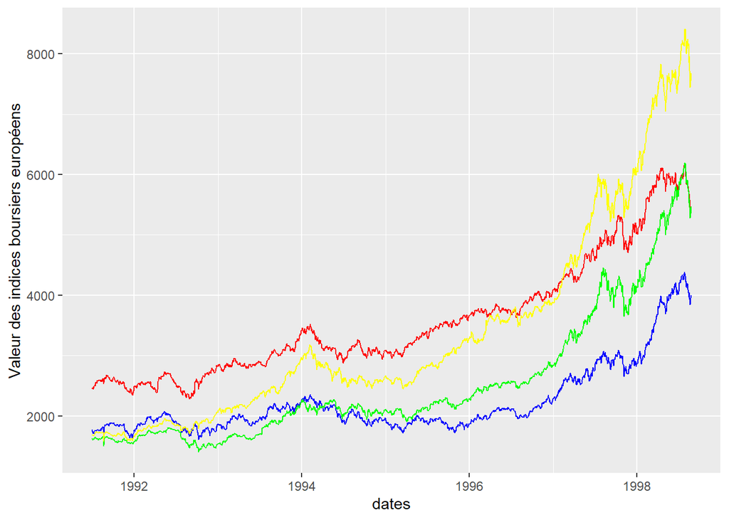

```r
# Séries temporelles
ggplot(data = EuStockMarkets_V1) +
  geom_line(mapping = aes( x = dates, y = CAC), colour = 'blue') +
  geom_line(mapping = aes( x = dates, y = FTSE), colour = 'red') +
  geom_line(mapping = aes( x = dates, y = DAX), colour = 'green') +
  geom_line(mapping = aes( x = dates, y = SMI), colour = 'yellow') +
  ylab('Valeur des indices boursiers européens')
```

L’ajout d’une légende pose problème pour l’instant nous verrons une solution plus tard.

## Relation entre deux variables qualitatives

Nous allons travailler sur un jeu de données de la library **questionr**.

```r
library(questionr)
data(hdv2003)
summary(hdv2003)
```

```
##        id              age           sexe
##  Min.   :   1.0   Min.   :18.00   Homme: 899
##  1st Qu.: 500.8   1st Qu.:35.00   Femme:1101
##  Median :1000.5   Median :48.00
##  Mean   :1000.5   Mean   :48.16
##  3rd Qu.:1500.2   3rd Qu.:60.00
##  Max.   :2000.0   Max.   :97.00
##
##                                                  nivetud        poids
##  Enseignement technique ou professionnel court       :463   Min.   :   78.08
##  Enseignement superieur y compris technique superieur:441   1st Qu.: 2221.82
##  Derniere annee d'etudes primaires                   :341   Median : 4631.19
##  1er cycle                                           :204   Mean   : 5535.61
##  2eme cycle                                          :183   3rd Qu.: 7626.53
##  (Other)                                             :256   Max.   :31092.14
##  NA's                                                :112
##                    occup                           qualif    freres.soeurs
##  Exerce une profession:1049   Employe                 :594   Min.   : 0.000
##  Chomeur              : 134   Ouvrier qualifie        :292   1st Qu.: 1.000
##  Etudiant, eleve      :  94   Cadre                   :260   Median : 2.000
##  Retraite             : 392   Ouvrier specialise      :203   Mean   : 3.283
##  Retire des affaires  :  77   Profession intermediaire:160   3rd Qu.: 5.000
##  Au foyer             : 171   (Other)                 :144   Max.   :22.000
##  Autre inactif        :  83   NA's                    :347
##           clso                              relig
##  Oui        : 936   Pratiquant regulier        :266
##  Non        :1037   Pratiquant occasionnel     :442
##  Ne sait pas:  27   Appartenance sans pratique :760
##                     Ni croyance ni appartenance:399
##                     Rejet                      : 93
##                     NSP ou NVPR                : 40
##
##                          trav.imp           trav.satisf  hard.rock  lecture.bd
##  Le plus important           : 29   Satisfaction  :480   Non:1986   Non:1953
##  Aussi important que le reste:259   Insatisfaction:117   Oui:  14   Oui:  47
##  Moins important que le reste:708   Equilibre     :451
##  Peu important               : 52   NA's          :952
##  NA's                        :952
##
##
##  peche.chasse cuisine    bricol     cinema     sport        heures.tv
##  Non:1776     Non:1119   Non:1147   Non:1174   Non:1277   Min.   : 0.000
##  Oui: 224     Oui: 881   Oui: 853   Oui: 826   Oui: 723   1st Qu.: 1.000
##                                                           Median : 2.000
##                                                           Mean   : 2.247
##                                                           3rd Qu.: 3.000
##                                                           Max.   :12.000
##                                                           NA's   :5
```

Nous pouvons éduier le lien entre le viveau d’étude **nivetud** et la pratique sportive **sport**. Pour étudier le lien entre deux variables qualitatives, on commence souvent par un tableau de contingence qui est un tableaux à double entrée indiquant des effectifs

```r
tab_contingence <- table(hdv2003$nivetud, hdv2003$sport)
tab_contingence
```

```
##
##                                                                   Non Oui
##   N'a jamais fait d'etudes                                         38   1
##   A arrete ses etudes, avant la derniere annee d'etudes primaires  78   8
##   Derniere annee d'etudes primaires                               300  41
##   1er cycle                                                       161  43
##   2eme cycle                                                      109  74
##   Enseignement technique ou professionnel court                   307 156
##   Enseignement technique ou professionnel long                     71  60
##   Enseignement superieur y compris technique superieur            186 255
```

On s’intéresse notamment aux pourcentages ligne

```r
lprop(tab_contingence)
```

```
##
##                                                                   Non   Oui
##   N'a jamais fait d'etudes                                         97.4   2.6
##   A arrete ses etudes, avant la derniere annee d'etudes primaires  90.7   9.3
##   Derniere annee d'etudes primaires                                88.0  12.0
##   1er cycle                                                        78.9  21.1
##   2eme cycle                                                       59.6  40.4
##   Enseignement technique ou professionnel court                    66.3  33.7
##   Enseignement technique ou professionnel long                     54.2  45.8
##   Enseignement superieur y compris technique superieur             42.2  57.8
##   Ensemble                                                         66.2  33.8
##
##                                                                   Total
##   N'a jamais fait d'etudes                                        100.0
##   A arrete ses etudes, avant la derniere annee d'etudes primaires 100.0
##   Derniere annee d'etudes primaires                               100.0
##   1er cycle                                                       100.0
##   2eme cycle                                                      100.0
##   Enseignement technique ou professionnel court                   100.0
##   Enseignement technique ou professionnel long                    100.0
##   Enseignement superieur y compris technique superieur            100.0
##   Ensemble                                                        100.0
```

et colonne

```r
cprop(tab_contingence)
```

```
##
##                                                                   Non   Oui
##   N'a jamais fait d'etudes                                          3.0   0.2
##   A arrete ses etudes, avant la derniere annee d'etudes primaires   6.2   1.3
##   Derniere annee d'etudes primaires                                24.0   6.4
##   1er cycle                                                        12.9   6.7
##   2eme cycle                                                        8.7  11.6
##   Enseignement technique ou professionnel court                    24.6  24.5
##   Enseignement technique ou professionnel long                      5.7   9.4
##   Enseignement superieur y compris technique superieur             14.9  40.0
##   Total                                                           100.0 100.0
##
##                                                                   Ensemble
##   N'a jamais fait d'etudes                                          2.1
##   A arrete ses etudes, avant la derniere annee d'etudes primaires   4.6
##   Derniere annee d'etudes primaires                                18.1
##   1er cycle                                                        10.8
##   2eme cycle                                                        9.7
##   Enseignement technique ou professionnel court                    24.5
##   Enseignement technique ou professionnel long                      6.9
##   Enseignement superieur y compris technique superieur             23.4
##   Total                                                           100.0
```

Ces informations peuvent être visualisées à l’aide de diagramme en barres. La variable **nivetud** comprends cependant trop de modalités (avec des noms trop long).

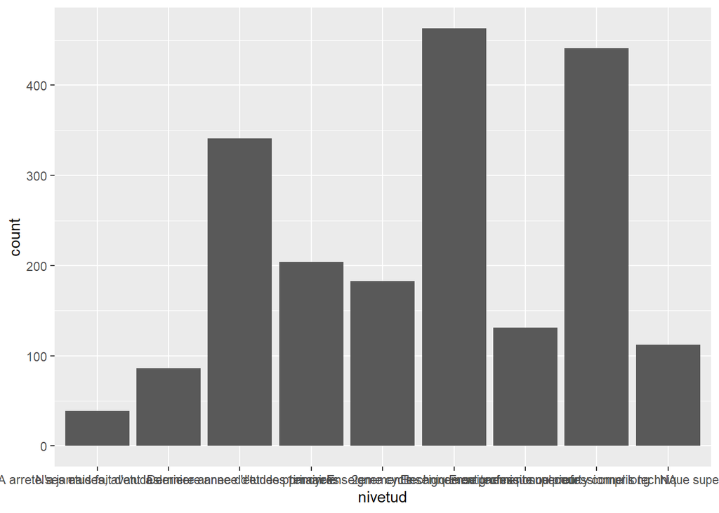

```r
ggplot(data = hdv2003) +
  geom_bar(aes(x = nivetud))
```

Nous réduisons le nombre de modalités à l’aide de la fonction **levels**

```r
data("hdv2003")
hdv2003$nivetud <- as.factor(hdv2003$nivetud)
levels(hdv2003$nivetud) <- c(rep('Primaire', 3), rep('Secondaire', 2), rep('Supérieur', 3))
table(hdv2003$nivetud)
```

```
##
##   Primaire Secondaire  Supérieur
##        466        387       1035
```

Nous pouvons soit produire avoir une barre pour chaque modalité de la première variable qualitative (ici **nivetud**) splittée en fonction du nombre d’occurence des modalités de la deuxième variable qualitative (**sport**).

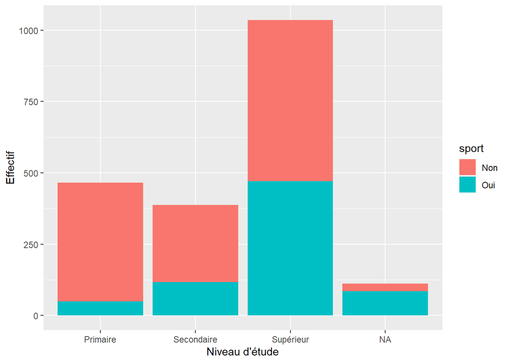

```r
ggplot(data = hdv2003) + geom_bar(mapping = aes(x = nivetud, fill = sport), position = "stack") +
  labs(x = "Niveau d'étude", y = "Effectif")
```

ou avoir une barre par modalité de la deuxième variable qualitative.

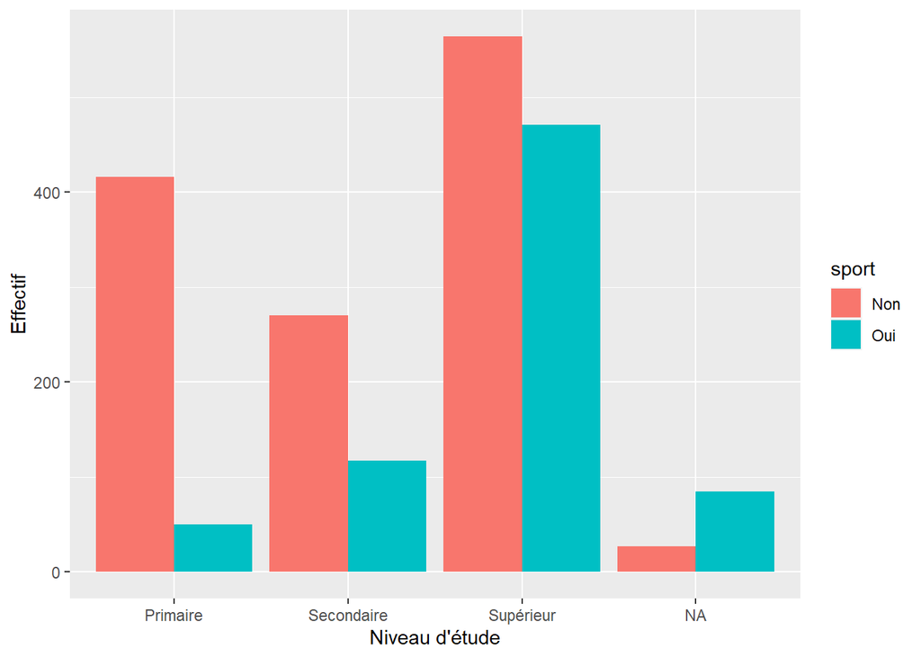

```r
ggplot(data = hdv2003) + geom_bar(mapping = aes(x = nivetud, fill = sport), position = "dodge") +
  labs(x = "Niveau d'étude", y = "Effectif")
```

## Variables quantitatives et qualitatives

Lorsque qu’on étudie le lien entre une variable qualitative et une variable quantitatives, on se sert de la variable qualitative pour segmenter le jeu de données. On se demande si la distribution de la variable quantitative est la même au sein des différents groupes définis par les modalités de la variable qualitative. On peut s’interesser par exemple à la sinistralité en fonction de la présence ou non d’un avocat.

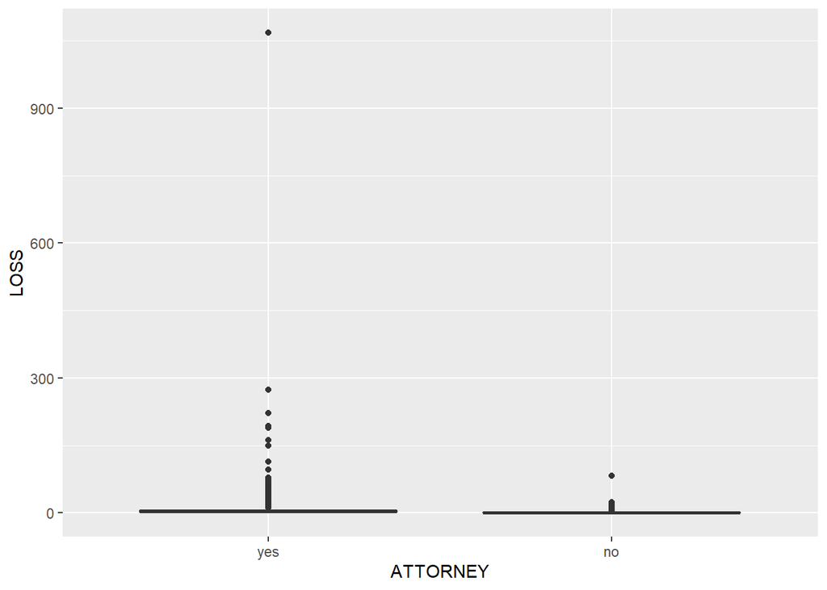

```r
library(insuranceData)
data(AutoBi)
# La variable ATTORNEY n'est pas traité automatiquement comme une variable qualitative et donc nécessite un pré-traitement
AutoBi$ATTORNEY <- as.factor(AutoBi$ATTORNEY)
levels(AutoBi$ATTORNEY) <- c('yes', 'no')
ggplot(data = AutoBi, aes(x = ATTORNEY, y = LOSS)) + geom_boxplot()
```

On peut aussi étudier l’intéraction entre deux variables quantitatives au sein des groupes définis par une variable qualitative. Par exemple, l’influence de la direction du vent dans la relation entre la température et le niveau d’ozone mesuré.

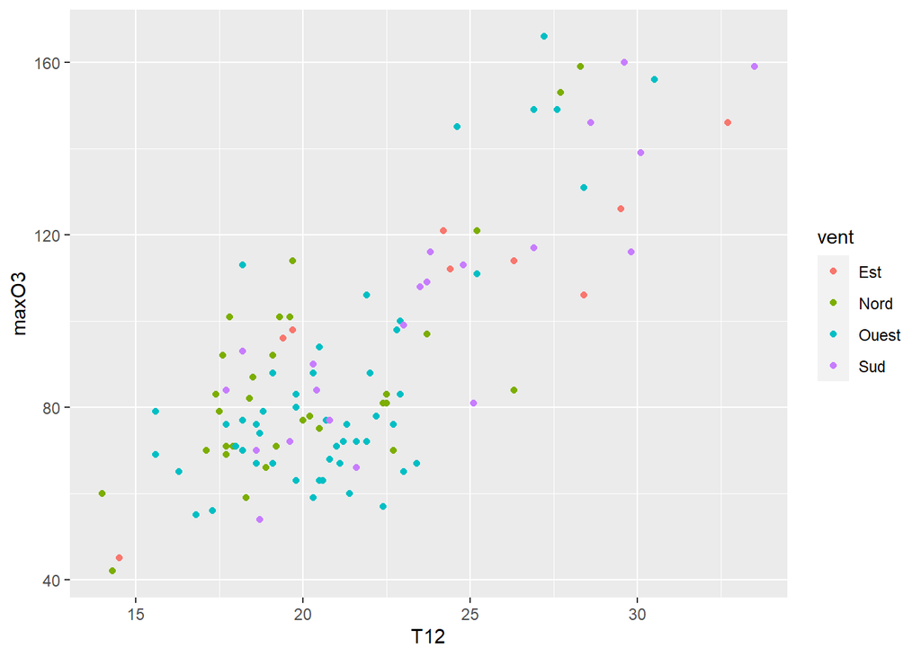

```r
ggplot(data = ozone) + geom_point(mapping = aes(x = T12, y = maxO3, color = vent))
```

Ce n’est pas hyper facile à lire, on peut utiliser la fonction **geom_smooth** afin d’exhiber des tendances.

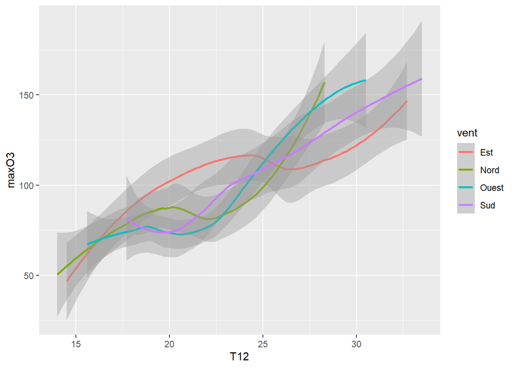

```r
ggplot(data = ozone,  aes(x = T12, y = maxO3, color = vent)) + geom_smooth()
```

A noter qu’une technique de regression polynomial est utilisée ici (**method = loess**). On constate le peu d’influence de la direction du vent. On revient sur l’exemple des séries temporelles. On va ajouter une légende en créant un nouveau jeu de données contenant une variable qualitative indiquant l’indice boursier considéré. Imaginons que l’on souhaite comparer l’évolution du CAC et du DAX.

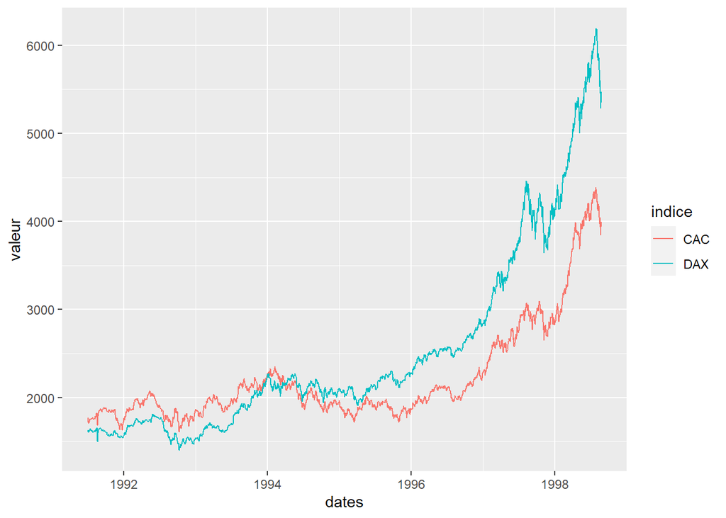

```r
# Data frame contenant les données correspondant au CAC
CAC <- data.frame(dates = EuStockMarkets_V1$dates, valeur = EuStockMarkets_V1$CAC, indice = 'CAC')
# Data frame contenant les données correspondant au DAX
DAX <- data.frame(dates = EuStockMarkets_V1$dates, valeur = EuStockMarkets_V1$DAX, indice = 'DAX')
# On concatène ces deux data frames
CAC_DAX = rbind(CAC, DAX)

# plus qu'à faire le graphique
ggplot(data =  CAC_DAX) + geom_line( mapping = aes(x = dates, y = valeur, colour = indice))
```

Il est possible d’enregistrer le dernier graphique produit à l’aide de la fonction **ggsave**. Pour l’occasion, nous allons changer le thème pour changer d’ambiance

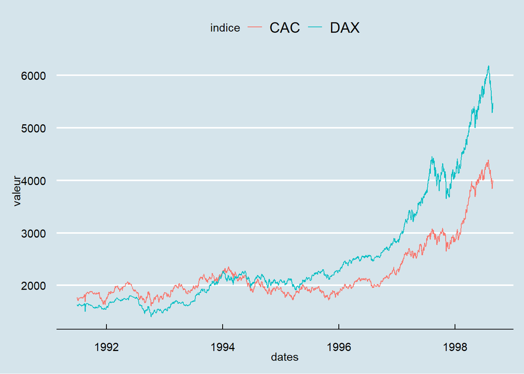

```r
library(ggthemes)
(p <- ggplot(data =  CAC_DAX) + geom_line( mapping = aes(x = dates, y = valeur, colour = indice)) + theme_economist())
```

```r
ggsave("indices_boursiers.pdf", plot = p, width = 11, height = 8)
```

# Référence

- [Graphiques univariés et bivariés avec ggplot2](http://larmarange.github.io/analyse-R/graphiques-bivaries-ggplot2.html), *blogpost*.
- Wickman, H. & Navarro, D. & Pedersen T. L. (2018). [ggplot2: Elegant Graphics for Data Analysis](https://ggplot2-book.org/). O’Reilly.
- Chang, W. [R Graphics cookbook](https://r-graphics.org/)
- Scherrer, Cédric [A ggplot2 tutorial for Beautiful plotting in R](https://www.cedricscherer.com/2019/08/05/a-ggplot2-tutorial-for-beautiful-plotting-in-r/?fbclid=IwAR3uRUJBCeRcQ46E1Z_GIWn0B4tE9KJiAHTRSi7tYxySmEuANgrEDVLQhJQ#prep)